# Do Improvements in Economic Development Lead to Better Population Health Outcomes in the US vs. China?

Fei Yi (2609012) · Sarah Shao (2608499) · Serena Gu (2609244) · Tianyi Grace Zhou (2644924) · Minna Lai (2599976)

## 1 Introduction

Economic development and population health are closely interconnected. As countries grow economically, infrastructure, and public services can contribute to better health outcomes. However, the timing and magnitude of these improvements may vary across countries depending on their stage of development.

This project investigates whether improvements in economic development lead to better population health outcomes by comparing the United States and China. The United States represents a mature, high-income economy with relatively stable growth, while China represents a rapidly developing economy that has experienced significant structural changes in recent decades.

Using data from the World Bank World Development Indicators (WDI), we analyze key economic indicators (GDP per capita and GDP growth) alongside health indicators (life expectancy and under-5 mortality rate). By examining trends over time and comparing the two countries, we aim to understand how economic development is associated with changes in population health.

## 2 Data Description

### 2.1 Data Source

The dataset used in this project is obtained from the World Bank World Development Indicators (WDI), a standardized database that provides economic and social indicators across countries and over time.

### 2.2 Variables

We focus on two countries, the United States (USA) and China (CHN), and select four key variables representing economic development and population health:

- GDP per capita (constant 2015 US$)
- GDP growth (annual %)
- Life expectancy at birth (years)
- Under-5 mortality rate (per 1,000 live births)

### 2.3 Data Processing

Data was retrieved using Python and merged into a unified dataset based on country and year. The resulting dataset has a panel structure, where each row represents a country-year observation.

Data cleaning was performed using SQL, including filtering relevant countries, standardizing variable names, and handling missing values. We restricted the dataset to the overlapping time period where all variables are available to ensure comparability.

The final dataset contains:  
`country`, `country_code`, `year`, `gdp_per_capita`, `gdp_growth`, `life_expectancy`, `mortality_under5`.

## 3 Data Analysis

This section presents four parts of the analysis. First, the economic analysis compares GDP per capita and GDP growth trends. Second, the health analysis compares life expectancy and under-5 mortality. Third, the comparison analysis examines cross-country gaps over time. Finally, the relationship analysis explores whether economic indicators are associated with health outcomes.

### 3.1 Summary Statistics

| country | gdp_per_capita | gdp_growth | life_expectancy | mortality_under5 |
| --- | --- | --- | --- | --- |
| China | 3442.07 | 8.73 | 70.12 | 42.86 |
| United States | 43744.02 | 2.75 | 75.85 | 11.02 |

The table summarizes average economic and health indicators for the United States and China over the study period. The United States has a substantially higher average GDP per capita, while China exhibits a higher average GDP growth rate. In terms of health outcomes, China has made significant progress, with increases in life expectancy and reductions in under-5 mortality, narrowing the gap with the United States.

### 3.2 Economic Analysis

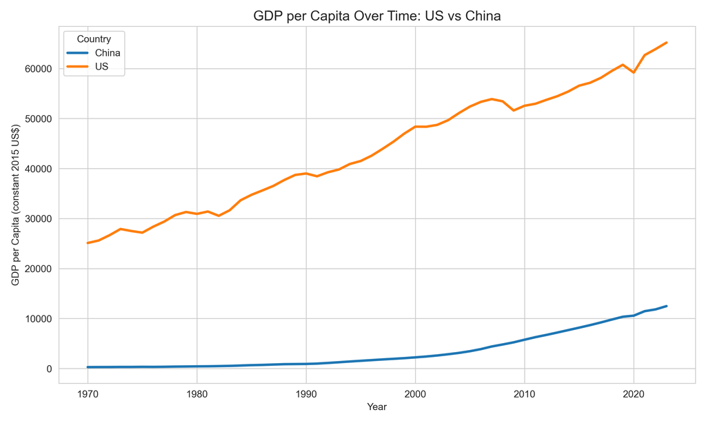

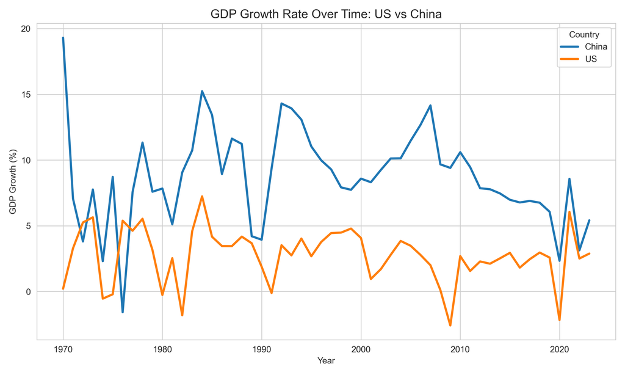

**Interpretation:**

The United States maintains a consistently higher GDP per capita than China throughout the study period, reflecting its status as a mature, high-income economy. In contrast, China shows rapid and sustained growth in GDP per capita, especially after the 1990s, indicating strong economic development over time.

GDP growth rates further highlight structural differences between the two countries. China exhibits higher but more volatile growth, characteristic of a rapidly developing economy undergoing structural transformation. The United States shows lower but more stable growth, reflecting economic maturity and resilience.

### 3.3 Health Analysis

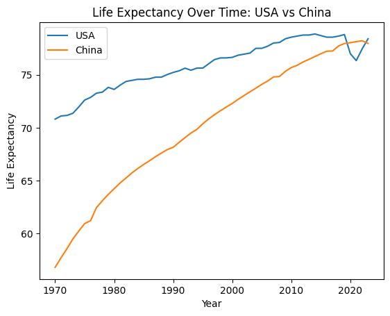

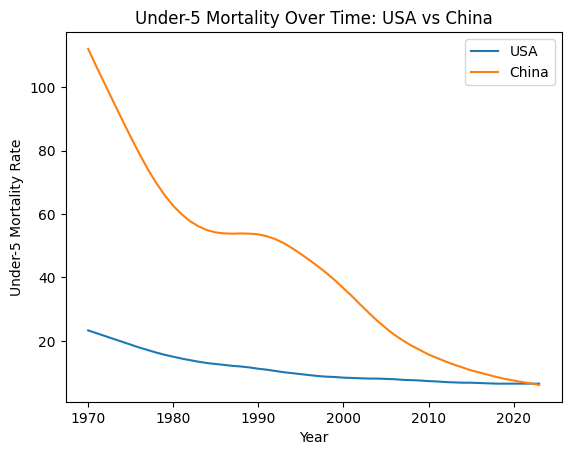

**Interpretation:**

### 3.4 Comparison Analysis

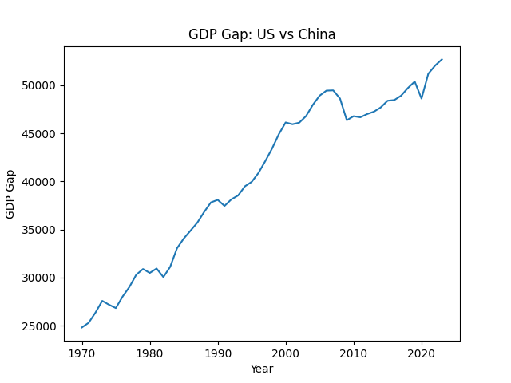

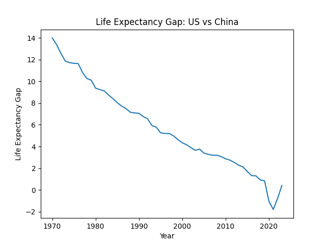

**Interpretation:**

The GDP per capita gap has widened over time, indicating that the income difference between the United States and China has increased rather than converged. This suggests a divergence in income levels despite China’s economic growth. In contrast, the life expectancy gap has nearly closed, suggesting that health outcomes can converge faster than income levels.

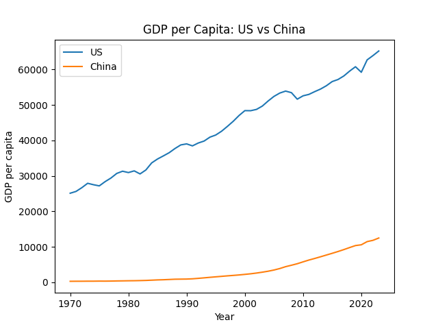

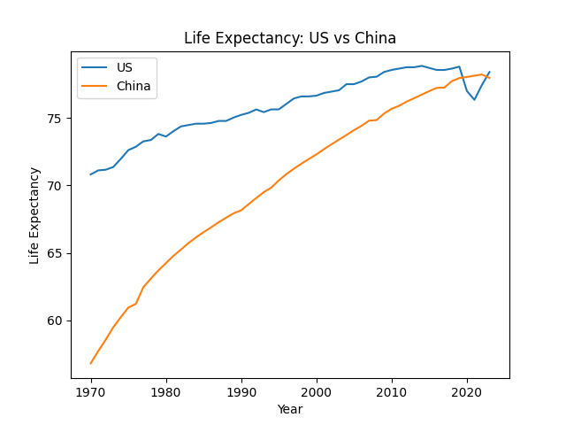

**Interpretation:**

The direct comparisons reinforce these patterns. The US maintains consistently high and stable income levels, while China shows a steep upward trajectory. For life expectancy, China’s continuous improvement has brought it close to US levels—a faster convergence than what is observed for GDP.

### 3.5 Relationship Analysis

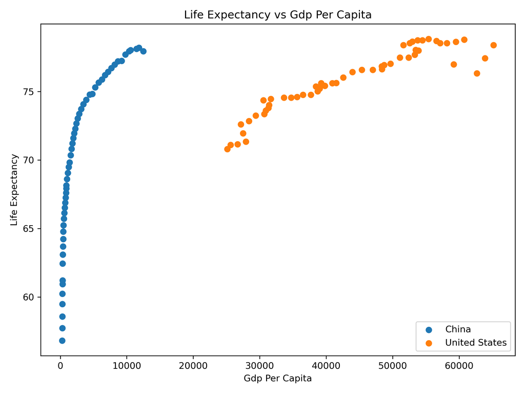

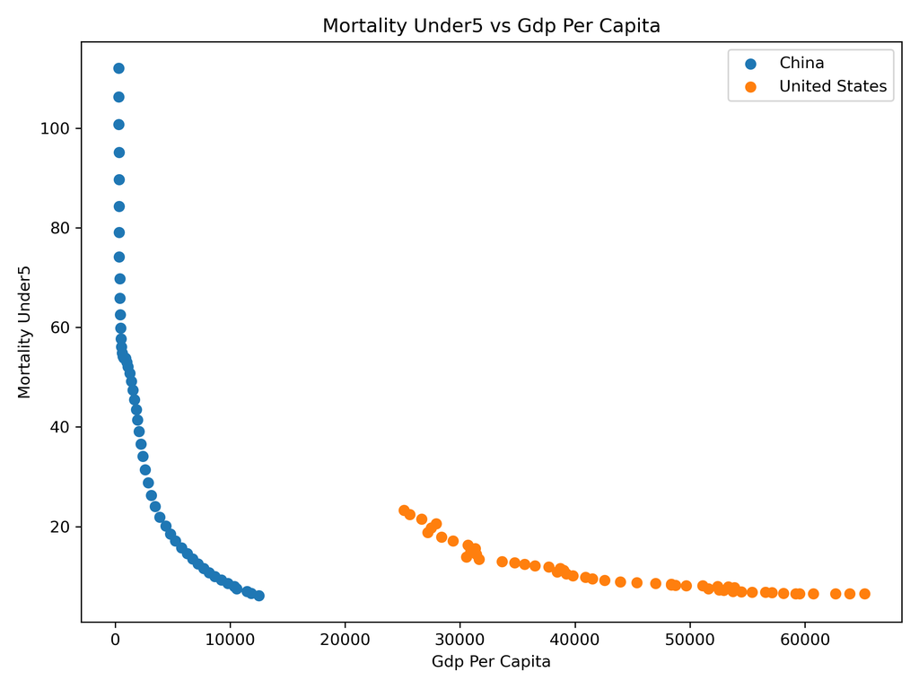

**Interpretation:**

GDP per capita is positively associated with life expectancy and negatively associated with under-5 mortality—higher income levels correspond to longer lives and lower child mortality. This relationship is especially pronounced for China, where rapid GDP growth coincides with large health gains.

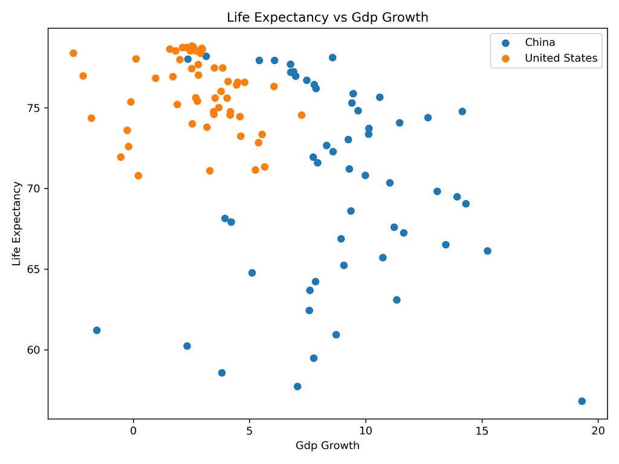

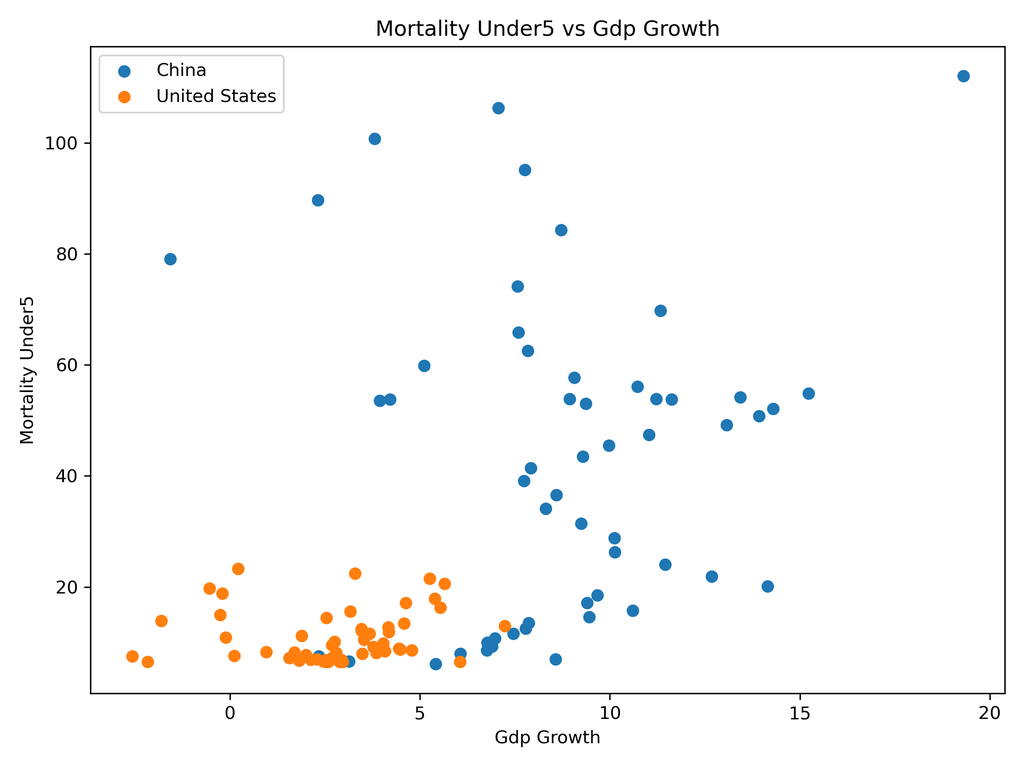

**Interpretation:**

GDP growth rate shows a weaker and less consistent relationship with both health indicators. Short-term annual growth fluctuations do not reliably predict changes in life expectancy or child mortality, suggesting that long-term income level matters more than short-term growth for population health.

## 4 Results and Discussion

### 4.1 Economic gaps remain large

China has experienced rapid economic growth over recent decades; however, this growth has not been sufficient to close the GDP per capita gap with the United States. Instead, the gap has generally widened over time. This indicates that although China is growing quickly, the absolute income difference remains large and continues to expand. China’s growth is higher but more volatile, while the US shows lower, more stable growth—with downturns like 2008 and 2020 clearly visible in the data.

### 4.2 Health outcomes converge faster than income

China shows strong improvements in life expectancy and under-5 mortality, converging toward US levels faster than income would predict. This suggests that health improvements are driven not only by rising income, but also by broader development processes such as public health investment, healthcare access, education, and sanitation.

### 4.3 Relationship between economic development and health

GDP per capita shows a strong and consistent association with better health outcomes—higher income levels link to longer life expectancy and lower child mortality. GDP growth rate, however, shows a weaker relationship, suggesting that long-term income level matters more than short-term growth fluctuations for population health.

### 4.4 Limitations

This analysis is limited to two countries, restricting generalizability. The results reflect correlations rather than causal relationships. Key confounding variables—such as healthcare policy, education, and environmental quality—are not explicitly controlled for, and data quality differences across countries may also affect the findings.

### 4.5 Overall interpretation

The findings suggest a meaningful but complex relationship between economic development and population health. Future research should include more countries, additional variables, and causal inference methods to better understand the underlying mechanisms.

## 5 Conclusion

This project examines the relationship between economic development and population health in the United States and China. While China has experienced rapid economic growth, a substantial income difference remains and the GDP per capita gap has not closed. In contrast, health outcomes—life expectancy and under-5 mortality—show much stronger convergence, suggesting that population health can improve faster than income. GDP per capita is more strongly associated with health outcomes than short-term GDP growth, highlighting the importance of long-term development over temporary fluctuations. As this analysis relies on correlations, findings should be interpreted as evidence of association rather than causation.

## 6 References

World Bank. (2024). *World Development Indicators*. https://databank.worldbank.org/source/world-development-indicators

World Bank. (2024). *GDP per capita (constant 2015 US$)*. https://data.worldbank.org/indicator/NY.GDP.PCAP.KD

World Bank. (2024). *GDP growth (annual %)*. https://data.worldbank.org/indicator/NY.GDP.MKTP.KD.ZG

World Bank. (2024). *Life expectancy at birth, total (years)*. https://data.worldbank.org/indicator/SP.DYN.LE00.IN

World Bank. (2024). *Mortality rate, under-5 (per 1,000 live births)*. https://data.worldbank.org/indicator/SH.DYN.MORT